# **Insurance Cost Analysis**

In this project, I have to perform analytics operations on an insurance database that uses the below mentioned parameters.

| Parameter | Description | Content type |
| --- | --- | --- |
| age | Age in years | integer |
| gender | Male or Female | integer (1 or 2) |
| BMI | Body mass index | float |
| no_of_children | Number of children | integer |
| smoker | Whether smoker or not | integer (0 or 1) |
| region | Which US region - NW, NE, SW, SE | integer (1,2,3 or 4 respectively) |
| charges | Annual Insurance charges in USD | float |

### Importing Required Libraries

```python
import numpy as np
import pandas as pd
import matplotlib.pyplot as plt
import seaborn as sns
%matplotlib inline
from sklearn.preprocessing import PolynomialFeatures
from sklearn.preprocessing import StandardScaler
from sklearn.model_selection import train_test_split
from sklearn.linear_model import LinearRegression
from sklearn.pipeline import Pipeline
from sklearn.metrics import r2_score
from sklearn.model_selection import cross_val_score
from sklearn.model_selection import GridSearchCV
from sklearn.linear_model import Ridge
```

## Importing the dataset

```python
path = 'https://cf-courses-data.s3.us.cloud-object-storage.appdomain.cloud/IBMDeveloperSkillsNetwork-DA0101EN-Coursera/medical_insurance_dataset.csv'
```

```python
df = pd.read_csv(path, header=None)
df.head(5)
```

|  | 0 | 1 | 2 | 3 | 4 | 5 | 6 |
| --- | --- | --- | --- | --- | --- | --- | --- |
| 0 | 19 | 1 | 27.900 | 0 | 1 | 3 | 16884.92400 |
| 1 | 18 | 2 | 33.770 | 1 | 0 | 4 | 1725.55230 |
| 2 | 28 | 2 | 33.000 | 3 | 0 | 4 | 4449.46200 |
| 3 | 33 | 2 | 22.705 | 0 | 0 | 1 | 21984.47061 |
| 4 | 32 | 2 | 28.880 | 0 | 0 | 1 | 3866.85520 |

Add the headers to the dataframe:

```python
df.columns = ['Age', 'Gender', 'BMI', 'No_of_Children', 'Smoker', 'Region', 'Charges']
df.head(5)
```

|  | Age | Gender | BMI | No_of_Children | Smoker | Region | Charges |
| --- | --- | --- | --- | --- | --- | --- | --- |
| 0 | 19 | 1 | 27.900 | 0 | 1 | 3 | 16884.92400 |
| 1 | 18 | 2 | 33.770 | 1 | 0 | 4 | 1725.55230 |
| 2 | 28 | 2 | 33.000 | 3 | 0 | 4 | 4449.46200 |
| 3 | 33 | 2 | 22.705 | 0 | 0 | 1 | 21984.47061 |
| 4 | 32 | 2 | 28.880 | 0 | 0 | 1 | 3866.85520 |

Replacing the '?' with NaN:

```python
df = df.replace('?', np.nan)
```

## Data Wrangling

```python
df.info()
```

```
<class 'pandas.core.frame.DataFrame'>
RangeIndex: 2772 entries, 0 to 2771
Data columns (total 7 columns):
 #   Column          Non-Null Count  Dtype
---  ------          --------------  -----
 0   Age             2768 non-null   object
 1   Gender          2772 non-null   int64
 2   BMI             2772 non-null   float64
 3   No_of_Children  2772 non-null   int64
 4   Smoker          2765 non-null   object
 5   Region          2772 non-null   int64
 6   Charges         2772 non-null   float64
dtypes: float64(2), int64(3), object(2)
memory usage: 151.7+ KB
```

**Missing data**:

```python
df.isnull().sum()[df.isnull().sum()>0]
```

```
Age       4
Smoker    7
dtype: int64
```

**Handling missing data**:

- Replacing age missing values with the sample mean.
- Replacing smoker missing values with the most frequent value.
- Updating the data types of the respective columns.

```python
df['Age'] = df['Age'].astype(float)
df['Age'] = df['Age'].replace(np.nan, np.mean(df['Age']))
df['Age'].isnull()[df['Age'].isnull()==True]
```

```
Series([], Name: Age, dtype: bool)
```

```python
df['Smoker'] = df['Smoker'].astype(float)
df['Smoker'] = df['Smoker'].replace(np.nan,0)
df['Smoker'].isnull()[df['Smoker'].isnull()==True]
```

```
Series([], Name: Smoker, dtype: bool)
```

Now we do not have ane missing data:

```python
df.isnull().sum()[df.isnull().sum()>0]
```

```
Series([], dtype: int64)
```

```python
df.info()
```

```
<class 'pandas.core.frame.DataFrame'>
RangeIndex: 2772 entries, 0 to 2771
Data columns (total 7 columns):
 #   Column          Non-Null Count  Dtype
---  ------          --------------  -----
 0   Age             2772 non-null   float64
 1   Gender          2772 non-null   int64
 2   BMI             2772 non-null   float64
 3   No_of_Children  2772 non-null   int64
 4   Smoker          2772 non-null   float64
 5   Region          2772 non-null   int64
 6   Charges         2772 non-null   float64
dtypes: float64(4), int64(3)
memory usage: 151.7 KB
```

## Exploratory Data Analysis (EDA)

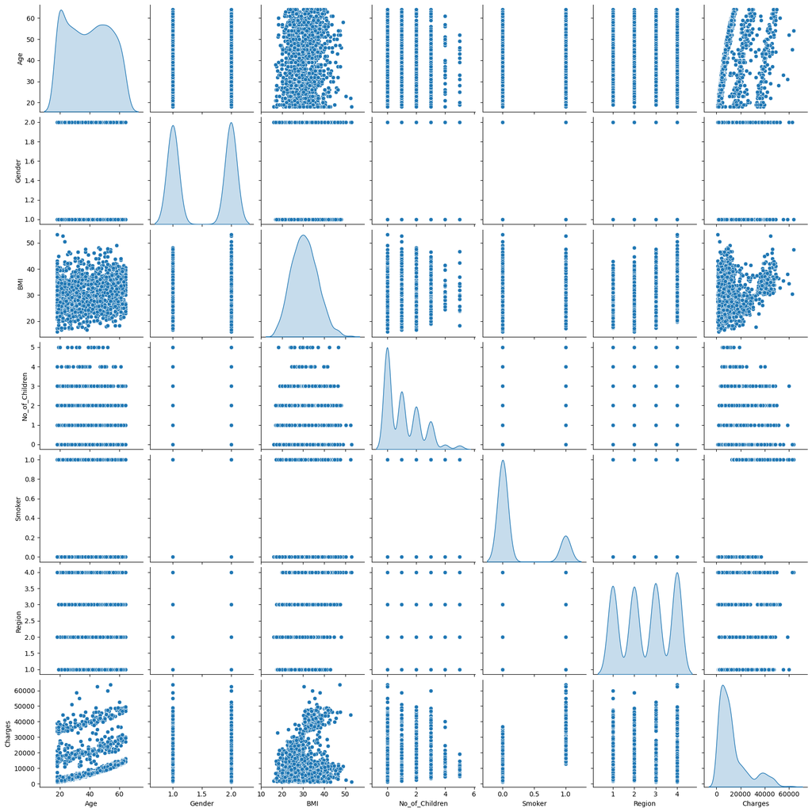

```python
sns.pairplot(df, diag_kind='kde')
```

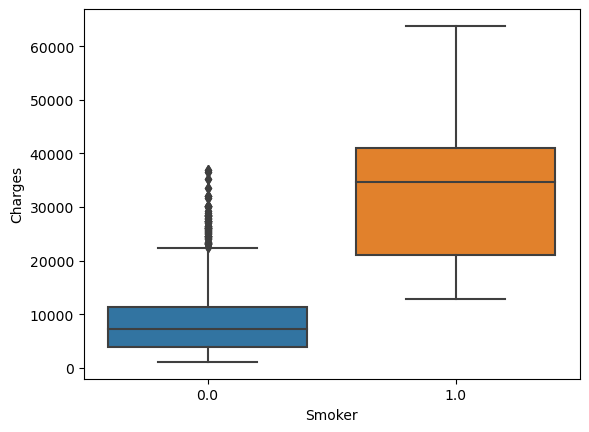

```python
sns.boxplot(x="Smoker", y="Charges", data=df)
plt.show()
```

We see that the distributions of charge between the smokers and non smokers have a significant difference, so smoking would be a good predictor of charges.

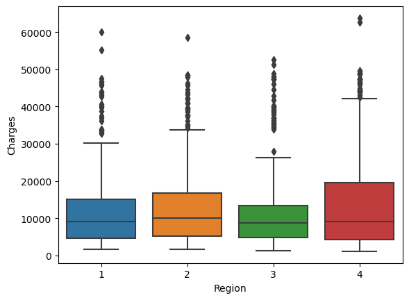

```python
sns.boxplot(x="Region", y="Charges", data=df)
plt.show()
```

It is obvious that the distributions of charge between the different regions have a significant overlap, so region may not be a good predictor of charge, but we'll invistegate it furthr on the model development stage.

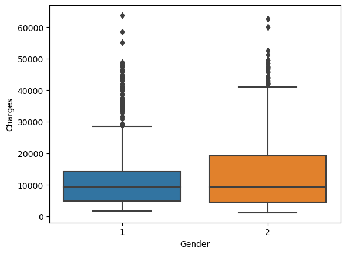

```python
sns.boxplot(x="Gender", y="Charges", data=df)
plt.show()
```

Here there is also a considerable overlap between genders. As such, `Gender` may not be a good predictor of `Charges`.

Now let's examine the correlation between the vriables by the correlation matrix for the dataset.

```python
df.corr()
```

|  | Age | Gender | BMI | No_of_Children | Smoker | Region | Charges |
| --- | --- | --- | --- | --- | --- | --- | --- |
| Age | 1.000000 | -0.026041 | 0.113045 | 0.037585 | -0.023285 | -0.007175 | 0.298622 |
| Gender | -0.026041 | 1.000000 | 0.042924 | 0.016020 | 0.082326 | 0.022213 | 0.062837 |
| BMI | 0.113045 | 0.042924 | 1.000000 | -0.001492 | 0.011489 | 0.271119 | 0.199846 |
| No_of_Children | 0.037585 | 0.016020 | -0.001492 | 1.000000 | 0.006362 | -0.025717 | 0.066442 |
| Smoker | -0.023285 | 0.082326 | 0.011489 | 0.006362 | 1.000000 | 0.054077 | 0.788783 |
| Region | -0.007175 | 0.022213 | 0.271119 | -0.025717 | 0.054077 | 1.000000 | 0.054058 |
| Charges | 0.298622 | 0.062837 | 0.199846 | 0.066442 | 0.788783 | 0.054058 | 1.000000 |

## Model Development

We'll fit a linear regression model that may be used to predict the `charges` value by using the `smoker` attribute, and refine based on adjusted R squared $ R^2_{a} $ and other transformations.

```python
def adjr2(model, x, y):
    r2 = model.score(x, y)
    n = len(y)
    p = np.array(x).shape[1]
    return 1 - ( 1 - r2 ) * ( n - 1 ) / ( n - p - 1 )
```

Now, we build several models by adding one feature each time and measure the performance based on $ R^2_{a} $

```python
x_data = df[['Smoker', 'BMI', 'Age', 'Region', 'No_of_Children']]
y_data = df[['Charges']]
models = [
    {'features': ['Smoker'], 'name': 'Model 1'},
    {'features': ['Smoker', 'BMI'], 'name': 'Model 2'},
    {'features': ['Smoker', 'BMI', 'Gender'], 'name': 'Model 3'},
    {'features': ['Smoker', 'BMI', 'Gender', 'Age'], 'name': 'Model 4'},
    {'features': ['Smoker', 'BMI', 'Gender', 'Age', 'Region'], 'name': 'Model 5' },
    {'features': ['Smoker', 'BMI', 'Gender', 'Age', 'Region', 'No_of_Children'], 'name': 'Model 6' }

]

results = []

for model_info in models:
    x_data = df[model_info['features']]
    model = LinearRegression().fit(x_data, y_data)
    adj_r2 = adjr2(model, x_data, y_data)
    results.append({'model': model_info['name'], 'adjusted_r2': adj_r2})

for result in results:
    print(f"{result['model']}: Adjusted R^2 = {result['adjusted_r2']}")
```

```
Model 1: Adjusted R^2 = 0.6220427744726635
Model 2: Adjusted R^2 = 0.6583359061342541
Model 3: Adjusted R^2 = 0.6583156918733235
Model 4: Adjusted R^2 = 0.7466441528642099
Model 5: Adjusted R^2 = 0.7474819620712256
Model 6: Adjusted R^2 = 0.7498647631725313
```

Notably, $ R^2_{a} $ value decreases in Model 3, indicating that the inclusion of the gender feature does not improve the model. Therefore, we will exclude this feature and retain the others.

```python
models = [
    {'features': ['Smoker'], 'name': 'Model 1'},
    {'features': ['Smoker', 'BMI'], 'name': 'Model 2'},
    {'features': ['Smoker', 'BMI', 'Age'], 'name': 'Model 3'},
    {'features': ['Smoker', 'BMI', 'Age', 'Region'], 'name': 'Model 4' },
    {'features': ['Smoker', 'BMI', 'Age', 'Region', 'No_of_Children'], 'name': 'Model 5' }

]

results = []

for model_info in models:
    x_data = df[model_info['features']]
    model = LinearRegression().fit(x_data, y_data)
    adj_r2 = adjr2(model, x_data, y_data)
    results.append({'model': model_info['name'], 'adjusted_r2': adj_r2})

for result in results:
    print(f"{result['model']}: Adjusted R^2 = {result['adjusted_r2']}")
```

```
Model 1: Adjusted R^2 = 0.6220427744726635
Model 2: Adjusted R^2 = 0.6583359061342541
Model 3: Adjusted R^2 = 0.7467335155784975
Model 4: Adjusted R^2 = 0.7475715262665471
Model 5: Adjusted R^2 = 0.7499506009588307
```

Based on adjusted R squared analysis, we conclude that the best predictors for charges are `Smoker`, `BMI`, `Age`, `Region`, and `No_of_Children`.

```python
x_data = df[['Smoker', 'BMI', 'Age', 'Region', 'No_of_Children']]
y_data = df[['Charges']]
lr = LinearRegression().fit(x_data, y_data)
```

To be more confident, we'll run $5-$fold **cross validation**:

```python
k = 5
r2_scores = cross_val_score(lr, x_data, y_data, cv=k)
print(r2_scores)
```

```
[0.73831385 0.75706073 0.76366983 0.74575582 0.74347314]
```

So our model is performing well on test data.

Let's examine the distribution of the predicted values of the data.

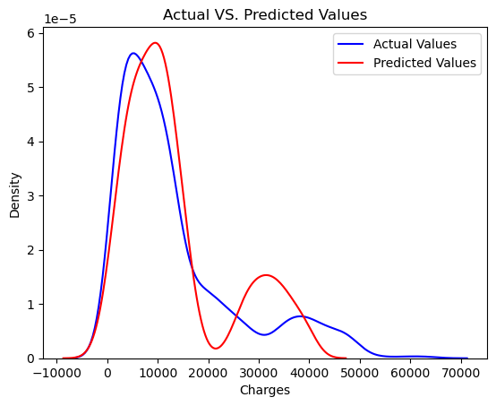

```python
data1 = np.array(y_data)
data2 = lr.predict(x_data)
sns.kdeplot(data1.reshape(data1.shape[0],), color="blue", label='Actual Values')
sns.kdeplot(data2.reshape(data2.shape[0],), color="red", label='Predicted Values')
plt.title('Actual VS. Predicted Values')
plt.xlabel('Charges')
plt.legend()
plt.show()
```

As we see in the distribution plot, there is a room for improvement.

## Model Refinement

Let's start by splitting the data into training and testing subsets, we're assuming that 20% of the data will be reserved for testing.

```python
x_train, x_test, y_train, y_test = train_test_split(x_data, y_data, test_size=0.2, random_state=1)
print("Number of test samples :", x_test.shape[0])
print("Number of train samples:",x_train.shape[0])
```

```
Number of test samples : 555
Number of train samples: 2217
```

We want to perform polynomial regression, we will see how the R^2 changes on the test data for different order polynomials and then plot the results:

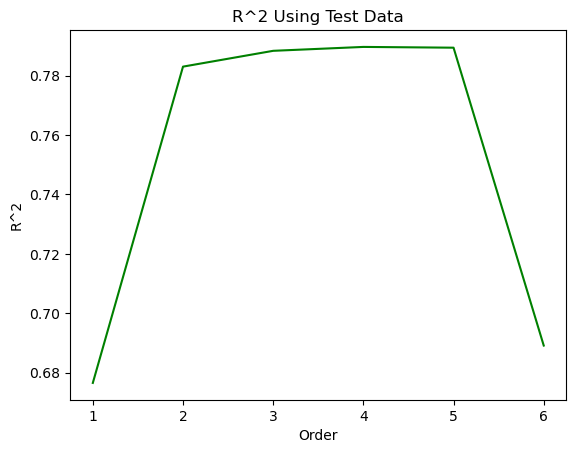

```python
Rsqu_test = []

order = [1, 2, 3, 4, 5, 6]

for n in order:
    pr = PolynomialFeatures(degree=n)

    x_train_pr = pr.fit_transform(x_train)

    x_test_pr = pr.fit_transform(x_test)

    lr.fit(x_train_pr, y_train)

    Rsqu_test.append(lr.score(x_test_pr, y_test))

plt.plot(order, Rsqu_test, color='g')
plt.xlabel('Order')
plt.ylabel('R^2')
plt.title('R^2 Using Test Data')
plt.show()
```

So from this analysis we conclude that the polynomial of order $4$ will have the best $ R^2 $

```python
p4 = PolynomialFeatures(degree=4)
x_train_p4 = p4.fit_transform(x_train)
x_test_p4 = p4.fit_transform(x_test)
poly = LinearRegression().fit(x_train_p4, y_train)
yhat_train_p4 = poly.predict(x_train_p4)
yhat_test_p4 = poly.predict(x_test_p4)
```

```python
scores = cross_val_score(poly, p4.fit_transform(x_data), y_data, cv=5)
scores.mean(), scores.std()
```

```
(0.8523069712667614, 0.008627880753277072)
```

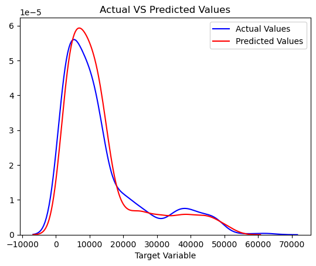

```python
data1 = np.array(y_train)
data2 = yhat_train_p4
sns.kdeplot(data1.reshape(data1.shape[0],), color="blue", label='Actual Values')
sns.kdeplot(data2.reshape(data2.shape[0],), color="red", label='Predicted Values')
plt.title('Actual VS Predicted Values')
plt.xlabel('Target Variable')
plt.ylabel('')
plt.legend()
plt.show()
```

Obviously, there is a notable improvement on the performance on the training data, let's see on the testin data:

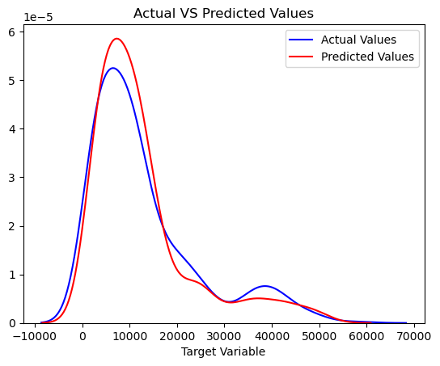

```python
data1 = np.array(y_test)
data2 = yhat_test_p4
sns.kdeplot(data1.reshape(data1.shape[0],), color="blue", label='Actual Values')
sns.kdeplot(data2.reshape(data2.shape[0],), color="red", label='Predicted Values')
plt.title('Actual VS Predicted Values')
plt.xlabel('Target Variable')
plt.ylabel('')
plt.legend()
plt.show()
```

Also a good performance on the testing data

Now we are going further step to see if it's possible to enhance the model more.

## Ridge regression

Creat a grid search to determine the best value for alpha.

```python
alpha_vals = [{'alpha': [0.001,0.1,1, 10, 100, 1000, 10000, 100000, 100000]}]
Grid = GridSearchCV(Ridge(), alpha_vals,cv=4)
Grid.fit(p4.fit_transform(x_data), y_data)
BestRR = Grid.best_estimator_
BestRR
```

[output not shown]

```
Ridge(alpha=0.001)
```

```python
scores = cross_val_score(BestRR, p4.fit_transform(x_data), y_data, cv=5)
scores.mean(), scores.std()
```

```
(0.8523122987320895, 0.008627636041075104)
```

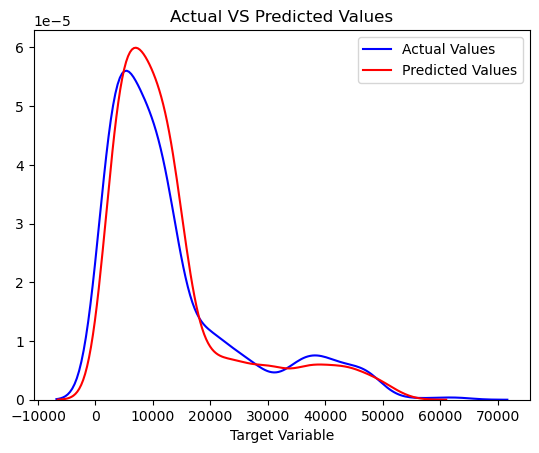

```python
data1 = np.array(y_train)
data2 = BestRR.predict(x_train_p4)
sns.kdeplot(data1.reshape(data1.shape[0],), color="blue", label='Actual Values')
sns.kdeplot(data2.reshape(data2.shape[0],), color="red", label='Predicted Values')
plt.title('Actual VS Predicted Values')
plt.xlabel('Target Variable')
plt.ylabel('')
plt.legend()
plt.show()
```

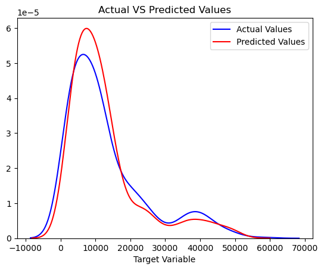

```python
data1 = np.array(y_test)
data2 = BestRR.predict(x_test_p4)
sns.kdeplot(data1.reshape(data1.shape[0],), color="blue", label='Actual Values')
sns.kdeplot(data2.reshape(data2.shape[0],), color="red", label='Predicted Values')
plt.title('Actual VS Predicted Values')
plt.xlabel('Target Variable')
plt.ylabel('')
plt.legend()
plt.show()
```

So this model is a little bit better than the previous one, so we will train it on the whole dataset to be ready for use.

```python
Best_Rige_Model = Ridge(alpha=0.001)
Best_Rige_Model.fit(p4.fit_transform(x_data), y_data)
Best_Rige_Model.score(p4.fit_transform(x_data), y_data)
```

```
0.861016821087218
```